# AlaskaSalmonSlides

May 29, 2018

## Alaska Salmon

This project is part of a class exercise where we create mini projects of our own. My project uses salmon spatial and biological data from A and C creek in Alaska collected from 2004 to 2016.

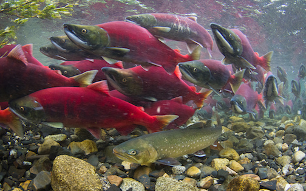

## Setting Up

We read in the file that we have that contains the spatial and biological data as well as the file that interprets spatial data into more recognizeable numerical values

```r
master <- read.csv("data/autocorrelation_sections_corrected_051118_final.csv", na.strings = "NA")
distances <- read.csv("data/creek_midpoint.csv")
```

## Cleaning up raw data

Due to years of data collection and many different people/minds collecting the data, there was variation in the input of data. Some variables were written in many different ways which needed to either be corrected or tossed away to better analyze the data.

## Tidyr

```r
master_with_distance_tidyr <- master_with_distance %>%
  filter(Year == 2004) %>%
  select(Year, Year_Tag, Date, location_section) %>%
  spread(key = Date, value = location_section)

kable(master_with_distance_tidyr)
```

| Year | Year_Tag | 7/27/04 | 7/28/04 | 7/29/04 | 7/30/04 | 7/31/04 | 8/1/04 | 8/10/04 | 8/11/04 | 8/12/04 | 8/13/04 | 8/14/04 | 8/16/04 | 8/2/04 | 8/20/04 | 8/21/04 | 8/22/04 | 8/23/04 | 8/25/04 | 8/27/04 | 8/28/04 | 8/3/04 | 8/4/04 | 8/5/04 | 8/6/04 | 8/7/04 | 8/8/04 | 8/9/04 |
| --- | --- | --- | --- | --- | --- | --- | --- | --- | --- | --- | --- | --- | --- | --- | --- | --- | --- | --- | --- | --- | --- | --- | --- | --- | --- | --- | --- | --- |
| 2004 | 2004_a-p1 | NA | NA | a_p | NA | NA | NA | NA | NA | NA | NA | NA | NA | NA | NA | NA | NA | NA | NA | NA | NA | NA | NA | NA | NA | NA | NA | NA |
| 2004 | 2004_a1601m | NA | NA | NA | NA | NA | NA | NA | NA | NA | NA | NA | a_j | NA | NA | NA | NA | NA | NA | NA | NA | NA | NA | NA | NA | NA | NA | NA |
| 2004 | 2004_a1602f | NA | NA | NA | NA | NA | NA | NA | NA | NA | NA | NA | a_l | NA | NA | NA | NA | NA | NA | NA | NA | NA | NA | NA | NA | NA | NA | NA |
| 2004 | 2004_a1603f | NA | NA | NA | NA | NA | NA | NA | NA | NA | NA | NA | a_l | NA | NA | NA | NA | NA | NA | NA | NA | NA | NA | NA | NA | NA | NA | NA |
| 2004 | 2004_a1604f | NA | NA | NA | NA | NA | NA | NA | NA | NA | NA | NA | a_l | NA | NA | NA | NA | NA | NA | NA | NA | NA | NA | NA | NA | NA | NA | NA |
| 2004 | 2004_a1605f | NA | NA | NA | NA | NA | NA | NA | NA | NA | NA | NA | a_n | NA | NA | NA | NA | NA | NA | NA | NA | NA | NA | NA | NA | NA | NA | NA |
| 2004 | 2004_a1606f | NA | NA | NA | NA | NA | NA | NA | NA | NA | NA | NA | a_p | NA | NA | NA | NA | NA | NA | NA | NA | NA | NA | NA | NA | NA | NA | NA |
| 2004 | 2004_a1607f | NA | NA | NA | NA | NA | NA | NA | NA | NA | NA | NA | a_z | NA | NA | NA | NA | NA | NA | NA | NA | NA | NA | NA | NA | NA | NA | NA |
| 2004 | 2004_a201 | NA | NA | NA | NA | NA | NA | NA | NA | NA | NA | NA | NA | a_NA | NA | NA | NA | NA | NA | NA | NA | NA | NA | NA | NA | NA | NA | NA |
| 2004 | 2004_a202 | NA | NA | NA | NA | NA | NA | NA | NA | NA | NA | NA | NA | a_NA | NA | NA | NA | NA | NA | NA | NA | NA | NA | NA | NA | NA | NA | NA |
| 2004 | 2004_a203 | NA | NA | NA | NA | NA | NA | NA | NA | NA | NA | NA | NA | a_NA | NA | NA | NA | NA | NA | NA | NA | NA | NA | NA | NA | NA | NA | NA |
| 2004 | 2004_a204 | NA | NA | NA | NA | NA | NA | NA | NA | NA | NA | NA | NA | a_NA | NA | NA | NA | NA | NA | NA | NA | NA | NA | NA | NA | NA | NA | NA |
| 2004 | 2004_a205 | NA | NA | NA | NA | NA | NA | NA | NA | NA | NA | NA | NA | a_NA | NA | NA | NA | NA | NA | NA | NA | NA | NA | NA | NA | NA | NA | NA |
| 2004 | 2004_a206 | NA | NA | NA | NA | NA | NA | NA | NA | NA | NA | NA | NA | a_NA | NA | NA | NA | NA | NA | NA | NA | NA | NA | NA | NA | NA | NA | NA |
| 2004 | 2004_a207 | NA | NA | NA | NA | NA | NA | NA | NA | NA | NA | NA | NA | a_NA | NA | NA | NA | NA | NA | NA | NA | NA | NA | NA | NA | NA | NA | NA |
| 2004 | 2004_a208 | NA | NA | NA | NA | NA | NA | NA | NA | NA | NA | NA | NA | NA | NA | NA | NA | NA | NA | NA | NA | NA | a_u | NA | NA | NA | NA | NA |
| 2004 | 2004_a209 | NA | NA | NA | NA | NA | NA | NA | NA | NA | NA | NA | NA | a_NA | NA | NA | NA | NA | NA | NA | NA | NA | NA | NA | NA | NA | NA | NA |
| 2004 | 2004_a210 | NA | NA | NA | NA | NA | NA | NA | NA | NA | NA | NA | NA | a_NA | NA | NA | NA | NA | NA | NA | NA | NA | NA | NA | NA | NA | NA | NA |
| 2004 | 2004_a211 | NA | NA | NA | NA | NA | NA | NA | NA | NA | NA | NA | NA | NA | NA | NA | NA | NA | NA | NA | NA | NA | a_p | NA | NA | NA | NA | NA |
| 2004 | 2004_a212 | NA | NA | NA | NA | NA | NA | NA | NA | NA | NA | NA | NA | a_NA | NA | NA | NA | NA | NA | NA | NA | NA | NA | NA | NA | NA | NA | NA |
| 2004 | 2004_a213 | NA | NA | NA | NA | NA | NA | NA | NA | NA | NA | NA | NA | NA | NA | NA | NA | NA | NA | NA | NA | NA | a_o | NA | NA | NA | NA | NA |
| 2004 | 2004_a214 | NA | NA | NA | NA | NA | NA | NA | NA | NA | NA | NA | NA | NA | NA | NA | NA | NA | NA | NA | NA | NA | a_i | NA | NA | NA | NA | NA |
| 2004 | 2004_a215 | NA | NA | NA | NA | NA | NA | NA | NA | NA | NA | NA | NA | NA | NA | NA | NA | NA | NA | NA | NA | NA | a_i | NA | NA | NA | NA | NA |
| 2004 | 2004_a216 | NA | NA | NA | NA | NA | NA | NA | NA | NA | NA | NA | NA | NA | NA | NA | NA | NA | NA | NA | NA | NA | a_h | NA | NA | NA | NA | NA |
| 2004 | 2004_a217 | NA | NA | NA | NA | NA | NA | NA | NA | NA | NA | NA | NA | NA | NA | NA | NA | NA | NA | NA | NA | NA | a_d | NA | NA | NA | NA | NA |
| 2004 | 2004_a218 | NA | NA | NA | NA | NA | NA | NA | NA | NA | NA | NA | NA | NA | NA | NA | NA | NA | NA | NA | NA | NA | a_d | NA | NA | NA | NA | NA |
| 2004 | 2004_a219 | NA | NA | NA | NA | NA | NA | NA | NA | NA | NA | NA | NA | NA | NA | NA | NA | NA | NA | NA | NA | NA | a_c | NA | NA | NA | NA | NA |
| 2004 | 2004_a303 | NA | NA | NA | NA | NA | NA | NA | NA | NA | NA | NA | NA | NA | NA | NA | NA | NA | NA | NA | NA | NA | NA | a_u | NA | NA | NA | NA |
| 2004 | 2004_a304 | NA | NA | NA | NA | NA | NA | NA | NA | NA | NA | NA | NA | NA | NA | NA | NA | NA | NA | NA | NA | NA | NA | a_r | NA | NA | NA | NA |
| 2004 | 2004_a305 | NA | NA | NA | NA | NA | NA | NA | NA | NA | NA | NA | NA | NA | NA | NA | NA | NA | NA | NA | NA | NA | NA | a_r | NA | NA | NA | NA |

[output cut: 995 more lines]

## Population dynamics

First, we will look at the ratio of males to females total in both creeks combined.

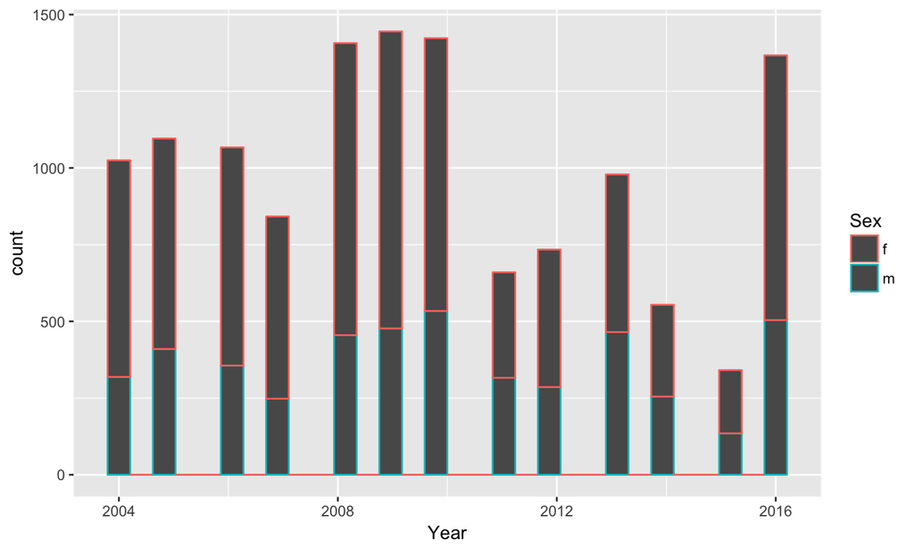

## Population Dynamics (cont.)

Then, we will look at the ratio of fish found in a vs c creek.

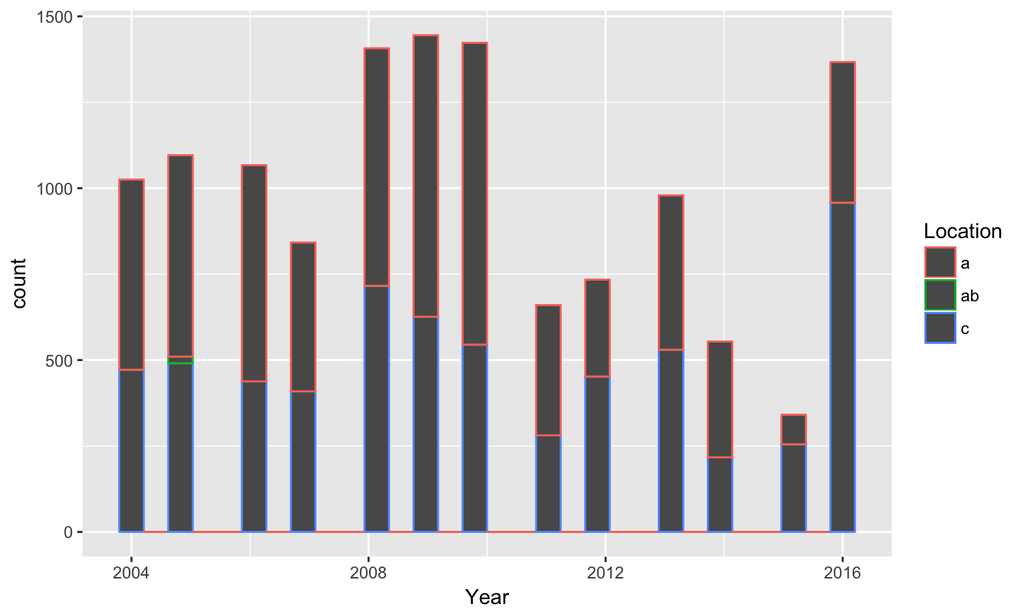

## Return times and distances each year between creeks

We must look at each creek and year separately. This didn't reveal any trends but data may need more cleaning up. **MUST** make edits to years and names accordingly when using this code. *The only year's available are 2004-2016*.

## Return times (cont.)

We will look at a creek in 2005…

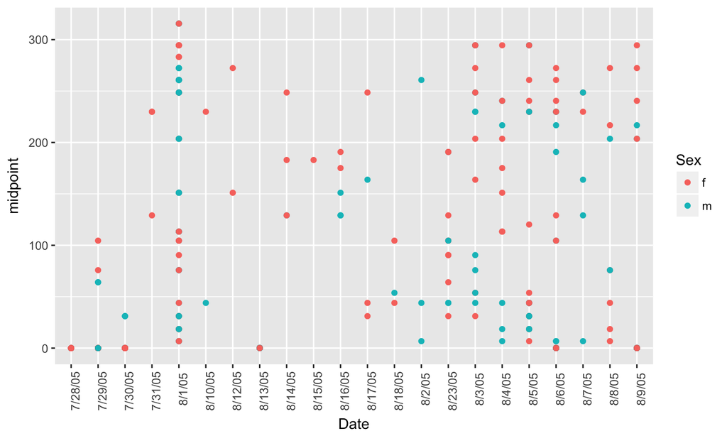

## Return times (cont.)

and c creek in 2005

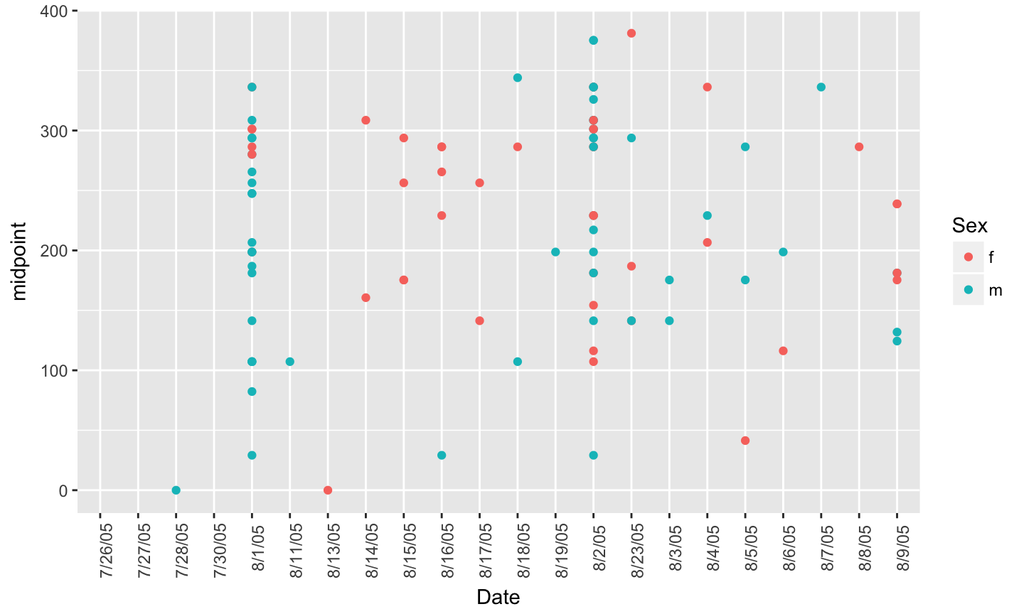

## Length of stay in creek

Determine the distribution of time that fish stay in the creek.

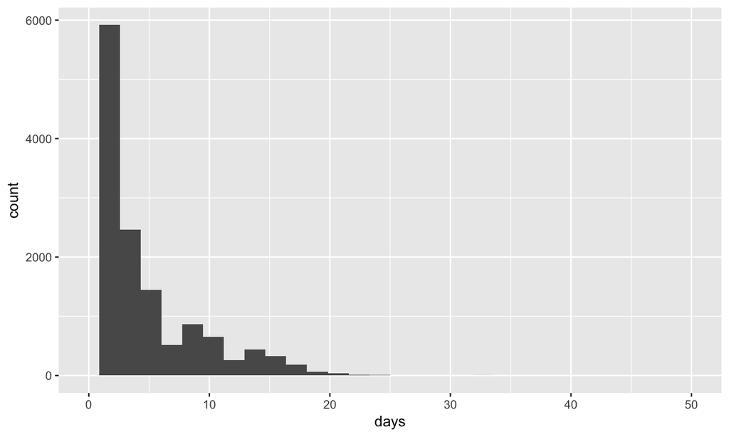

## Fish Density in section between years

A high fish density could mean preferable location of redds. More questions about density dependence can be asked, including how it affects the precision of homing. Again, it is important to change the year or creek section accordingly [^1]!!!

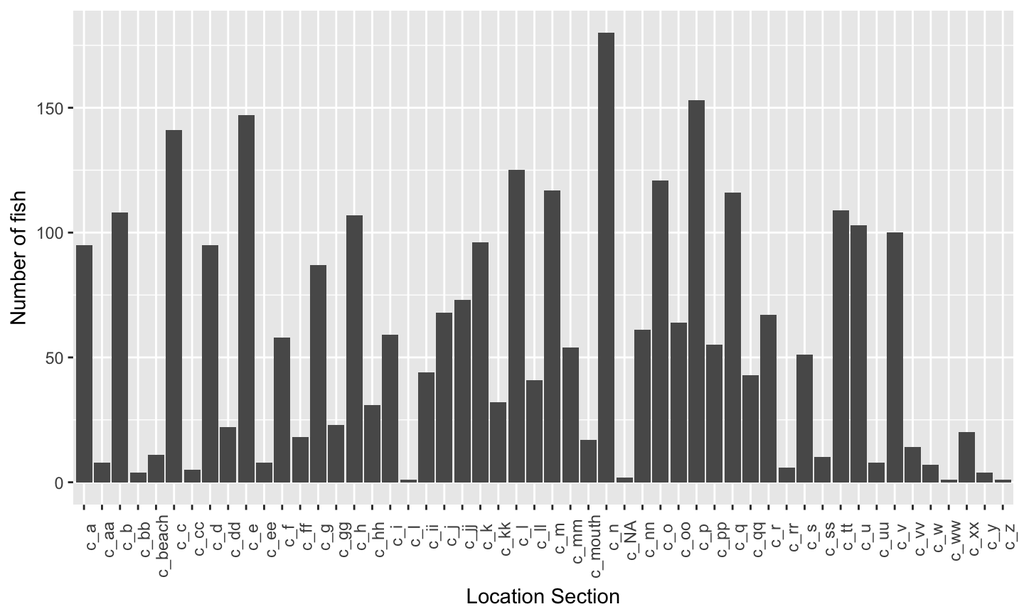

## Fish Density (cont.)

A more detailed look at the section density but showing how it varies per year

For C creek

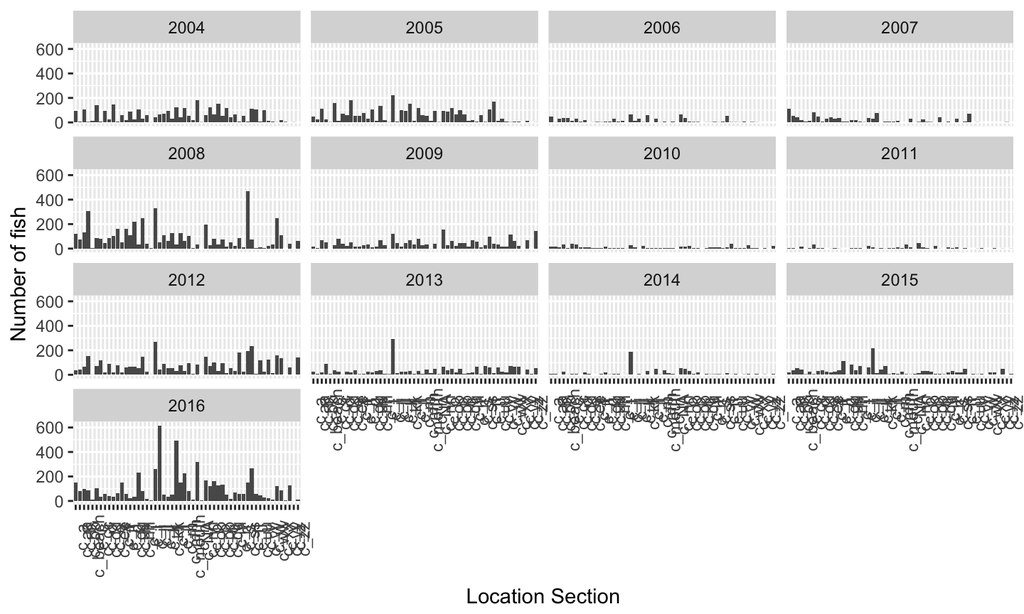

## Fish Density (cont.)

for A creek

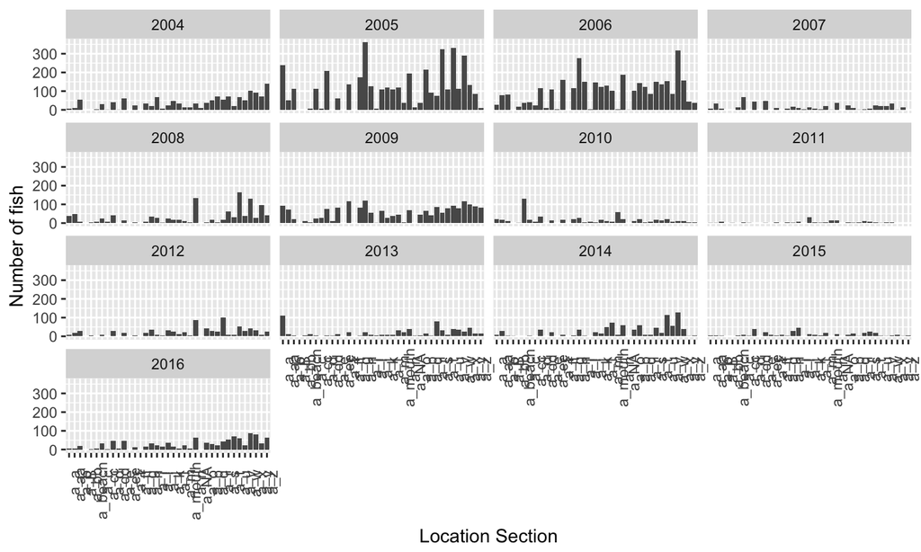